# Assignment-5

PLOTTING THE HIERARCHIAL CLUSTERING ALGORITHM

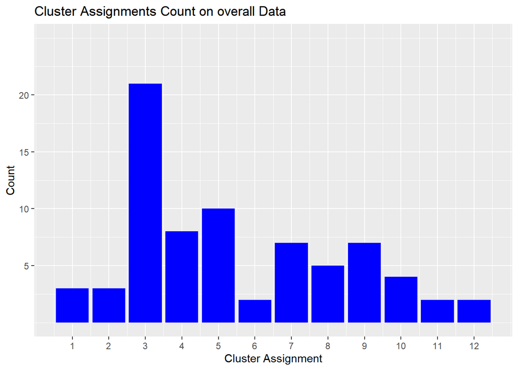

```r
# Visualize the cluster assignments to see any difference between the two
# Plot of original hierarchical clustering algorithm
ggplot(data = cereal_preprocessed_1, aes(cereal_preprocessed_1$cluster)) +
 geom_bar(fill = "BLUE") +
 labs(title="Cluster Assignments Count on overall Data") +
 labs(x="Cluster Assignment", y="Count") +
 guides(fill=FALSE) +
 scale_x_continuous(breaks=c(1:12)) +
 scale_y_continuous(breaks=c(5,10,15,20), limits = c(0,25))
```

```r
## Warning: The `<scale>` argument of `guides()` cannot be `FALSE`. Use "none" instead as
## of ggplot2 3.3.4.
```

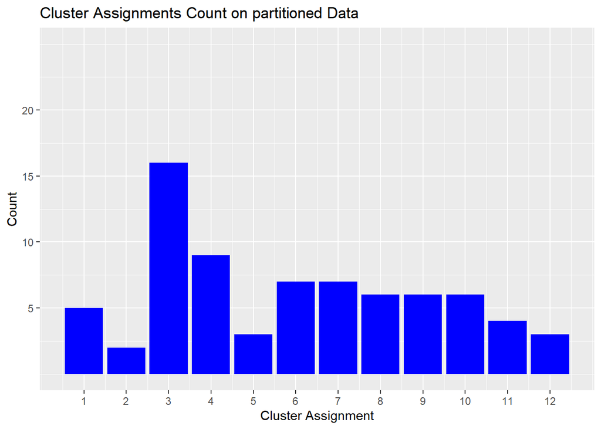

```r
# Plot the graph for the partitioned data
ggplot(data = cereal_preprocessed_2, aes(cereal_preprocessed_2$cluster)) +
 geom_bar(fill = "BLUE") +
 labs(title="Cluster Assignments Count on partitioned Data") +
 labs(x="Cluster Assignment", y="Count") +
 guides(fill=FALSE) +
 scale_x_continuous(breaks=c(1:12)) +
 scale_y_continuous(breaks=c(5,10,15,20), limits = c(0,25))
```

Visually, it is evident that once the data was divided, Cluster 3 shrank significantly. As a result, the size of some of the other clusters increased. The graphic suggests that when the data is partitioned, the clusters are distributed more equally among the 12 clusters.

TASK - 4 The elementary public schools would like to choose a set of cereals to include in their daily cafeterias. Every day a different cereal is offered, but all cereals should support a healthy diet. For this goal, you are requested to find a cluster of “healthy cereals.” Should the data be normalized? If not, how should they be used in the cluster analysis?

In this case, normalising the data wouldn’t be appropriate. It would not be appropriate since the nutritional information for cereal must be scaled or normalised based on the cereal sample that is being assessed. Because of this, the dataset that was gathered could only include cereals with a very high sugar content and minimal amounts of fibre, iron, or other nutrients. It is difficult to forecast how much nutrition a child will receive from cereal after it has been scaled or standardised throughout the sample set. A cereal with an iron content of 0.999 can lead an uninformed observer to believe that it provides almost all of the nutritive iron a kid needs, but it might also be the worst cereal in the sample set, having very little nutritious value.

Therefore, a more appropriate method to preprocess the data would be to make it a ratio to the daily needed quantities of calories, fibre, carbohydrates, etc. for a youngster. This would allow analysts to make better conclusions about the clusters during evaluation by preventing a small number of important elements from overriding the distance calculations. When analysing the clusters, an analyst may determine how much of a student’s required daily intake of nutrients would come from XX cereal by looking at the cluster average. After that, the employees would have the information to select from a range of “healthy” cereal clusters.